# Maps in Data Visualization: A Comprehensive Lecture

## Introduction

Maps are powerful tools for visualizing spatial data. They allow us to understand geographic patterns, spatial relationships, and regional variations in our data. However, creating effective map visualizations requires careful consideration of various factors including projection, color schemes, data classification, and more.

## 1. Why Use Maps for Data Visualization?

Maps are particularly useful when: - The geographic context is central to understanding the data - Spatial patterns or clusters are important to identify - Regional comparisons need to be made - Location-based decision making is required

## 2. Types of Maps in Data Visualization

### Choropleth Maps

These maps use color or shading to represent different values across geographic areas.

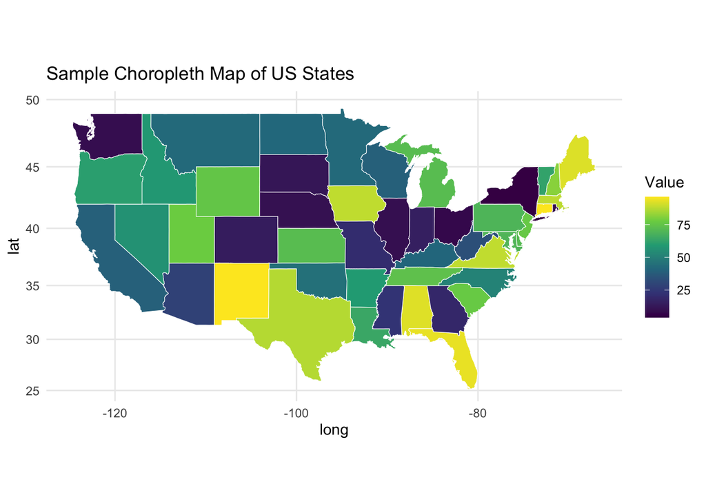

```r
# Example of a basic choropleth map in R
library(ggplot2)
library(maps)

# Get US states map data
states_map <- map_data("state")

# Create sample data
state_data <- data.frame(
  state = tolower(state.name),
  value = runif(50, 0, 100)
)

# Join the data
map_data <- merge(states_map, state_data, by.x = "region", by.y = "state")
map_data <- map_data[order(map_data$order), ]

# Create the map
ggplot(map_data, aes(x = long, y = lat, group = group, fill = value)) +
  geom_polygon(color = "white", size = 0.2) +
  coord_map() +
  scale_fill_viridis_c() +
  theme_minimal() +
  labs(title = "Sample Choropleth Map of US States",
       fill = "Value")
```

### Proportional Symbol Maps

These use differently sized symbols (usually circles) to represent data values at specific locations.

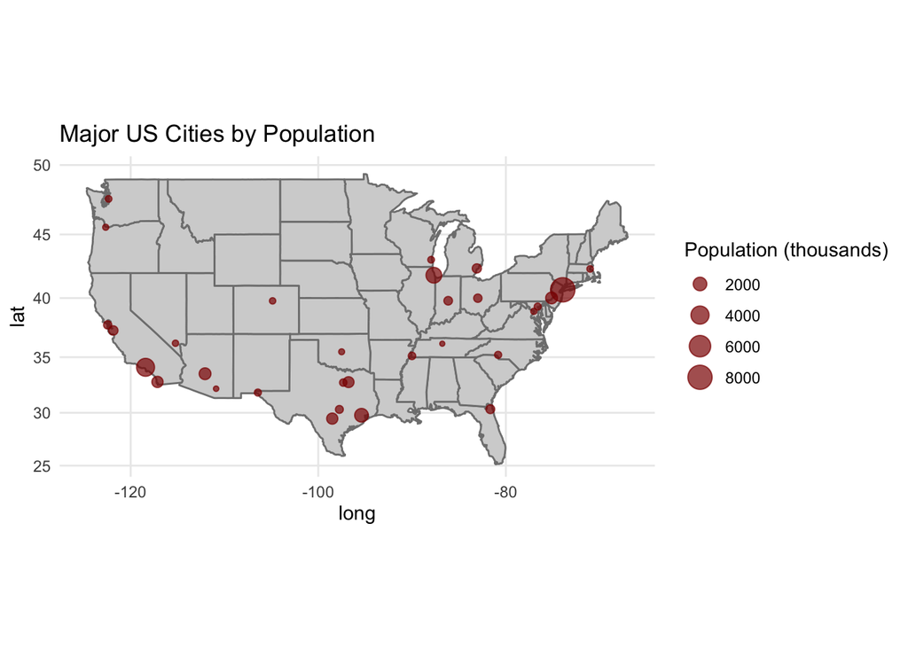

```r
library(ggplot2)
library(maps)

# Get US cities data
data(us.cities)

# Subset to major cities
major_cities <- us.cities[us.cities$pop > 500000, ]

# Create the map
ggplot() +
  borders("state", fill = "lightgray", color = "white") +
  geom_point(data = major_cities,
             aes(x = long, y = lat, size = pop/1000),
             color = "darkred", alpha = 0.7) +
  coord_map() +
  scale_size_continuous(name = "Population (thousands)") +
  theme_minimal() +
  labs(title = "Major US Cities by Population")
```

### Dot Density Maps

These use dots to represent the presence or density of a phenomenon.

### Flow Maps

These show movement or connections between locations.

### Heat Maps (Density Maps)

These visualize the intensity or concentration of data points across a geographic area.

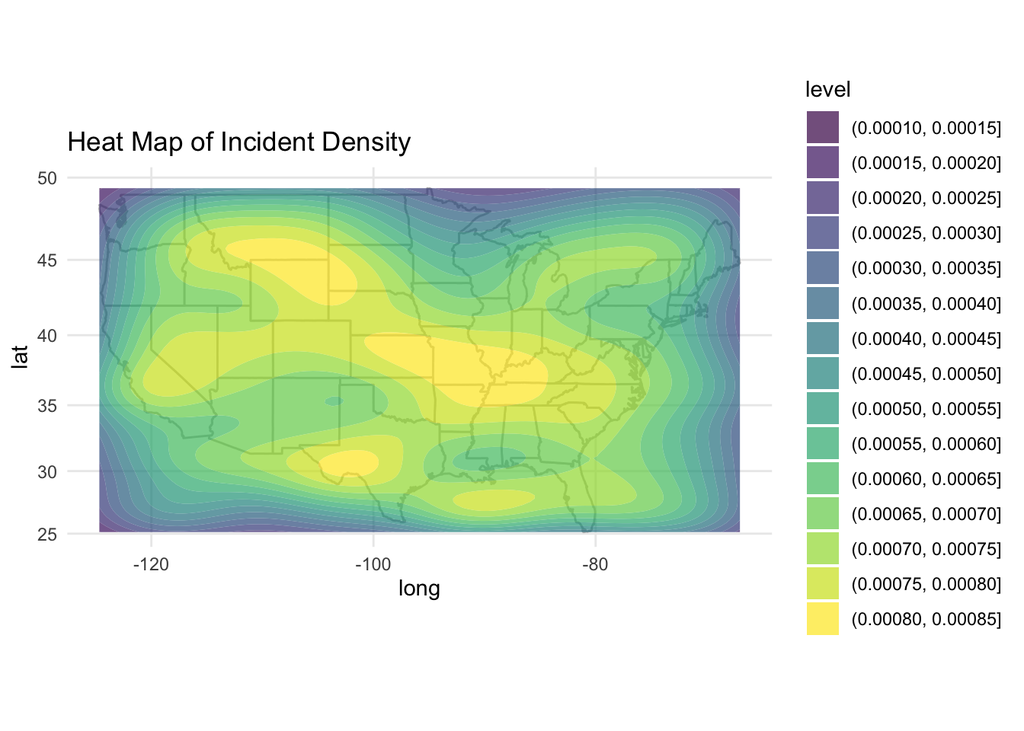

```r
library(ggplot2)
library(maps)

# Get US states map data
states_map <- map_data("state")

# Create sample point data (e.g., incidents)
set.seed(123)
incidents <- data.frame(
  long = runif(1000, min(states_map$long), max(states_map$long)),
  lat = runif(1000, min(states_map$lat), max(states_map$lat))
)

# Create the map
ggplot() +
  geom_polygon(data = states_map,
               aes(x = long, y = lat, group = group),
               fill = "white", color = "gray") +
  geom_density_2d_filled(data = incidents,
                        aes(x = long, y = lat),
                        alpha = 0.7) +
  coord_map() +
  theme_minimal() +
  labs(title = "Heat Map of Incident Density")
```

## 3. Key Considerations for Effective Map Visualizations

### Data Projection

Map projections transform the Earth’s 3D surface onto a 2D plane. Different projections preserve different properties:

- Equal-area projections (maintain area relationships)
- Conformal projections (maintain shape/angles)
- Equidistant projections (maintain distances)
- Compromise projections (balance multiple properties)

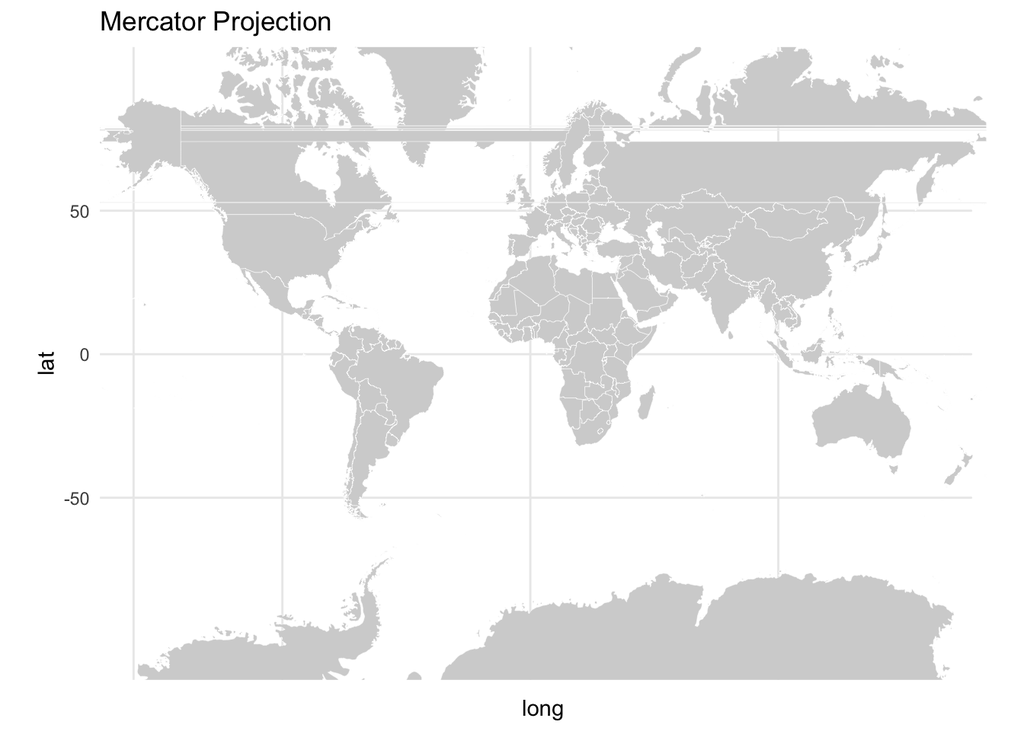

```r
# Example of different projections in R
library(ggplot2)
library(maps)

world <- map_data("world")

# Mercator projection (traditional but distorts areas)
p1 <- ggplot(world, aes(x = long, y = lat, group = group)) +
  geom_polygon(fill = "lightgray", color = "white", size = 0.1) +
  coord_map("mercator") +
  theme_minimal() +
  ggtitle("Mercator Projection")

# Albers equal-area projection
p2 <- ggplot(world, aes(x = long, y = lat, group = group)) +
  geom_polygon(fill = "lightgray", color = "white", size = 0.1) +
  coord_map("albers", lat0 = 0, lat1 = 0) +
  theme_minimal() +
  ggtitle("Albers Equal-Area Projection")
p1
```

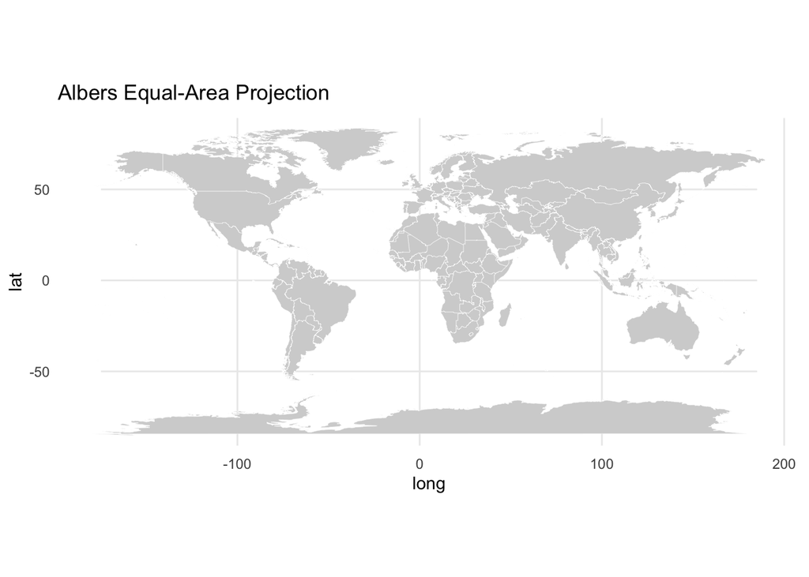

```r
p2
```

### Data Classification

How you group or bin your data can significantly impact the story your map tells:

- Equal intervals (equal range of values)
- Quantiles (equal number of observations)
- Natural breaks (finds natural groupings in the data)
- Standard deviation (shows deviation from the mean)

```r
library(ggplot2)
library(maps)
library(classInt)

# Get US states map data
states_map <- map_data("state")

# Create sample data
set.seed(42)
state_data <- data.frame(
  state = tolower(state.name),
  value = runif(50, 0, 100)
)

# Join the data
map_data <- merge(states_map, state_data, by.x = "region", by.y = "state")
map_data <- map_data[order(map_data$order), ]

# Create equal interval breaks
equal_intervals <- classIntervals(state_data$value, n = 5, style = "equal")
state_data$equal_int <- cut(state_data$value, breaks = equal_intervals$brks)

# Create quantile breaks
quantile_breaks <- classIntervals(state_data$value, n = 5, style = "quantile")
state_data$quantiles <- cut(state_data$value, breaks = quantile_breaks$brks)

# Create natural breaks
jenks_breaks <- classIntervals(state_data$value, n = 5, style = "jenks")
state_data$jenks <- cut(state_data$value, breaks = jenks_breaks$brks)
```

### Color Selection

Color choice is crucial for effective map visualization:

- Sequential color schemes for continuous data
- Diverging color schemes for data with a meaningful midpoint
- Qualitative color schemes for categorical data
- Consideration for colorblindness and accessibility

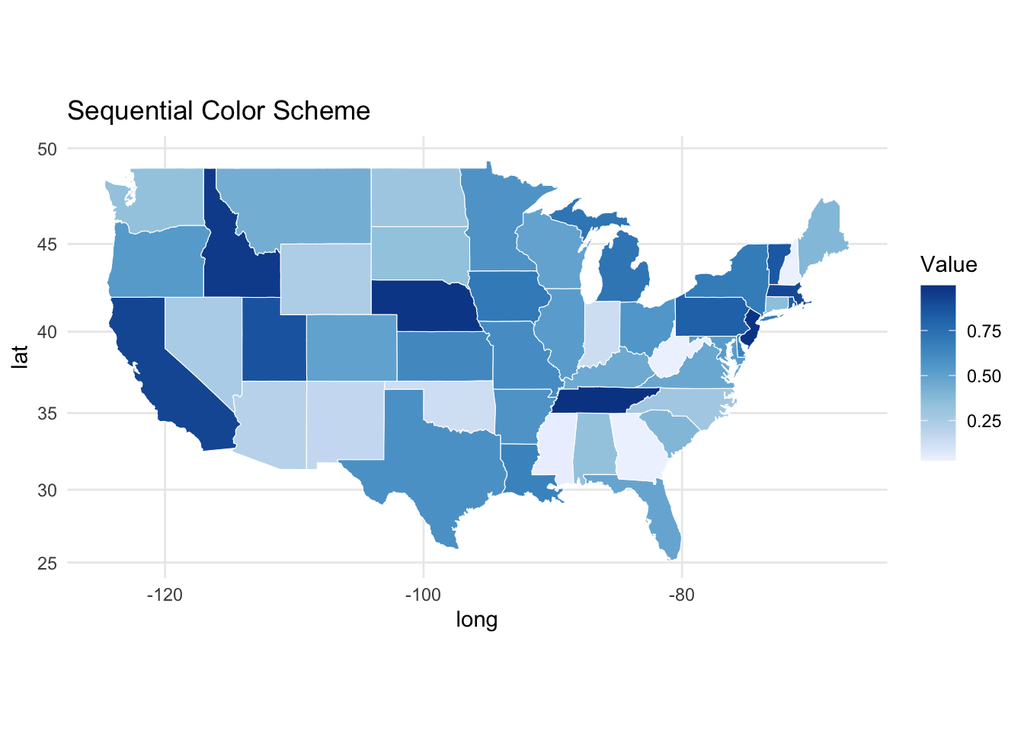

```r
library(ggplot2)
library(maps)
library(RColorBrewer)

# Get US states map data
states_map <- map_data("state")

# Create sample data
state_data <- data.frame(
  state = tolower(state.name),
  value = runif(50, -1, 1)  # Values range from -1 to 1
)

# Join the data
map_data <- merge(states_map, state_data, by.x = "region", by.y = "state")
map_data <- map_data[order(map_data$order), ]

# Sequential color scheme (for positive values only)
p1 <- ggplot(map_data, aes(x = long, y = lat, group = group, fill = abs(value))) +
  geom_polygon(color = "white", size = 0.2) +
  coord_map() +
  scale_fill_distiller(palette = "Blues", direction = 1) +
  theme_minimal() +
  labs(title = "Sequential Color Scheme", fill = "Value")

# Diverging color scheme (for values centered around 0)
p2 <- ggplot(map_data, aes(x = long, y = lat, group = group, fill = value)) +
  geom_polygon(color = "white", size = 0.2) +
  coord_map() +
  scale_fill_distiller(palette = "RdBu", direction = 1) +
  theme_minimal() +
  labs(title = "Diverging Color Scheme", fill = "Value")
p1
```

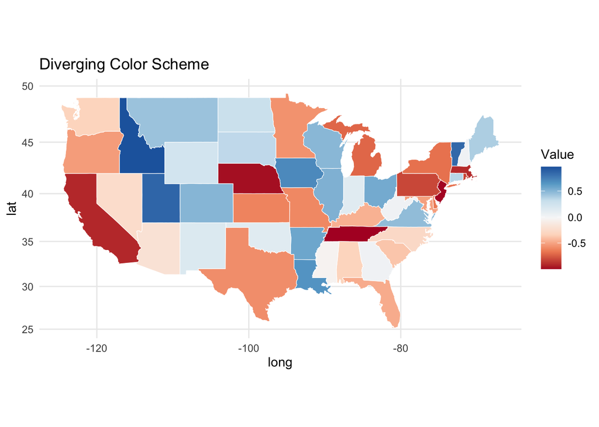

```r
p2
```

### Scale and Resolution

- Choose an appropriate scale for your visualization
- Consider the resolution of your data and the map boundaries
- Pay attention to small areas (they might disappear or be overemphasized)

### Context and Orientation

- Include necessary contextual elements (scale bar, north arrow, legend)
- Ensure the orientation is clear and conventional
- Include relevant geographic features for context

```r
library(ggplot2)
library(maps)
library(ggspatial)

# Get US states map data
states_map <- map_data("state")

# Create sample data
state_data <- data.frame(
  state = tolower(state.name),
  value = runif(50, 0, 100)
)

# Join the data
map_data <- merge(states_map, state_data, by.x = "region", by.y = "state")
map_data <- map_data[order(map_data$order), ]

# Create the map with context elements
# ggplot(map_data, aes(x = long, y = lat, group = group, fill = value)) +
#   geom_polygon(color = "white", size = 0.2) +
#   coord_map() +
#   scale_fill_viridis_c(name = "Value") +
#   theme_minimal() +
#   annotation_north_arrow(location = "bl", which_north = "true") +
#   annotation_scale(location = "br") +
#   labs(title = "US States with Scale and North Arrow")
```

## 4. Common Pitfalls to Avoid

### 1. Ignoring Map Projections

Using an inappropriate projection can severely distort your data. For example, the Mercator projection drastically exaggerates areas far from the equator.

### 2. Poor Color Choices

- Using rainbow color scales (difficult to interpret)
- Ignoring colorblindness considerations
- Using too many colors

### 3. Missing Context

- Maps without legends
- Lack of labeled reference points
- No indication of scale

### 4. Choropleth Fallacies

- Using raw counts instead of rates in choropleth maps
- Not accounting for population density
- Assuming uniform distribution within regions

```r
# Example of correcting for population in R
library(ggplot2)
library(maps)

# Get US states map data
states_map <- map_data("state")

# Create sample data
state_data <- data.frame(
  state = tolower(state.name),
  incidents = rpois(50, lambda = 1000),  # Raw counts
  population = state.x77[, "Population"] * 1000  # Population data
)

# Calculate rates
state_data$rate <- (state_data$incidents / state_data$population) * 100000  # per 100,000 people

# Join the data
map_data_count <- merge(states_map, state_data[, c("state", "incidents")],
                  by.x = "region", by.y = "state")
map_data_count <- map_data_count[order(map_data_count$order), ]

map_data_rate <- merge(states_map, state_data[, c("state", "rate")],
                  by.x = "region", by.y = "state")
map_data_rate <- map_data_rate[order(map_data_rate$order), ]

# Plot raw counts (misleading)
p1 <- ggplot(map_data_count, aes(x = long, y = lat, group = group, fill = incidents)) +
  geom_polygon(color = "white", size = 0.2) +
  coord_map() +
  scale_fill_viridis_c() +
  theme_minimal() +
  labs(title = "Raw Incident Counts (Misleading)",
       fill = "Incidents")

# Plot rates (more accurate)
p2 <- ggplot(map_data_rate, aes(x = long, y = lat, group = group, fill = rate)) +
  geom_polygon(color = "white", size = 0.2) +
  coord_map() +
  scale_fill_viridis_c() +
  theme_minimal() +
  labs(title = "Incident Rates per 100,000 People (Better)",
       fill = "Rate")
```

### 5. Overplotting or Oversimplification

- Too much detail can overwhelm
- Too little detail can mislead

### 6. Ignoring the Modifiable Areal Unit Problem (MAUP)

The pattern you see might change depending on how you aggregate spatial data.

## 5. Advanced Techniques

### Interactive Maps

Using packages like `leaflet` or `plotly` to create interactive maps that allow users to explore the data.

```r
library(leaflet)

# Create a leaflet map
leaflet() %>%
  addTiles() %>%  # Add default OpenStreetMap tiles
  setView(lng = -98, lat = 39, zoom = 4) %>%  # Center on US
  addCircleMarkers(
    data = us.cities[us.cities$pop > 500000, ],
    lng = ~long,
    lat = ~lat,
    radius = ~pop/500000,
    color = "red",
    fillOpacity = 0.7,
    popup = ~paste(name, "<br>Population:", pop)
  )
```

[interactive chart not shown]

### Small Multiples

Using a grid of small maps to compare different variables or time periods.

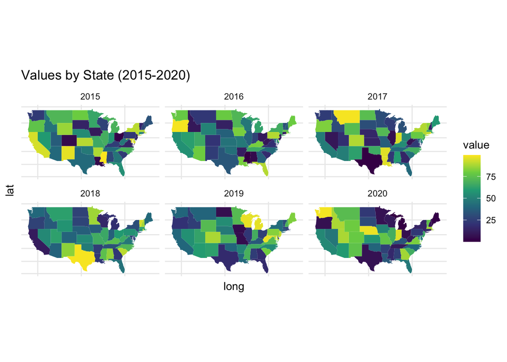

```r
library(ggplot2)
library(maps)
library(dplyr)
# Get US states map data
states_map <- map_data("state")

# Create sample data for multiple years
set.seed(123)
years <- 2015:2020
state_data <- expand.grid(
  state = tolower(state.name),
  year = years
)
state_data$value <- runif(nrow(state_data), 0, 100)

# Create the small multiples map
ggplot() +
  geom_polygon(data = states_map,
               aes(x = long, y = lat, group = group),
               fill = "lightgray", color = "white") +
  geom_polygon(data = inner_join(states_map, state_data, by = c("region" = "state")),
               aes(x = long, y = lat, group = group, fill = value)) +
  coord_map() +
  scale_fill_viridis_c() +
  facet_wrap(~year) +
  theme_minimal() +
  theme(axis.text = element_blank(),
        axis.ticks = element_blank()) +
  labs(title = "Values by State (2015-2020)")
```

### Bivariate Maps

Showing two variables simultaneously on a single map.

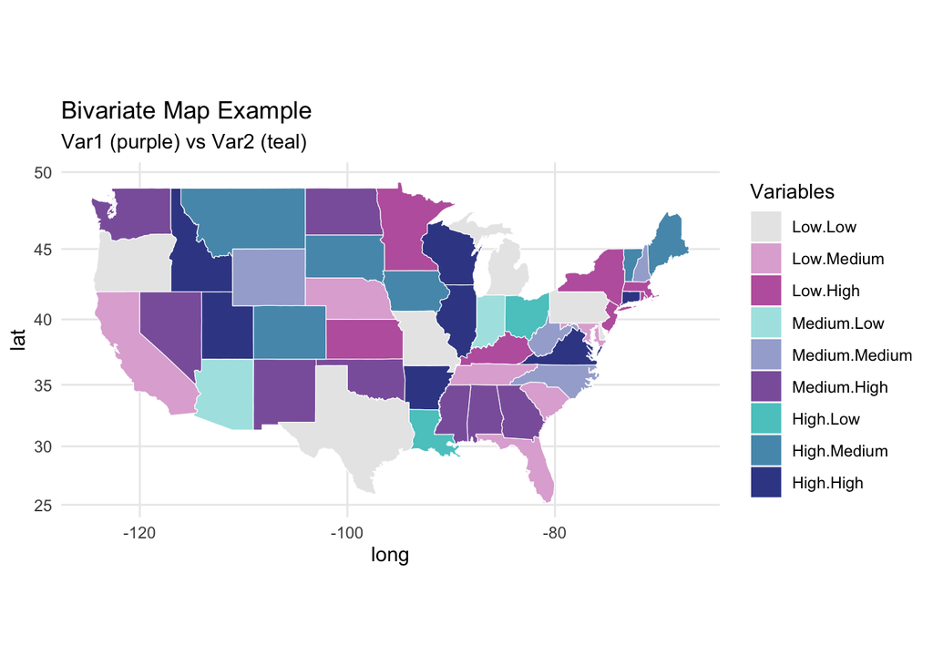

```r
library(ggplot2)
library(maps)

# Get US states map data
states_map <- map_data("state")

# Create sample data with two variables
set.seed(42)
state_data <- data.frame(
  state = tolower(state.name),
  var1 = runif(50, 0, 100),  # First variable
  var2 = runif(50, 0, 100)   # Second variable
)

# Discretize the variables
state_data$var1_cat <- cut(state_data$var1, breaks = c(0, 33, 66, 100), labels = c("Low", "Medium", "High"))
state_data$var2_cat <- cut(state_data$var2, breaks = c(0, 33, 66, 100), labels = c("Low", "Medium", "High"))

# Create a combined variable
state_data$bivar <- interaction(state_data$var1_cat, state_data$var2_cat)

# Create a color mapping
bivar_colors <- c(
  "Low.Low" = "#e8e8e8",
  "Low.Medium" = "#ace4e4",
  "Low.High" = "#5ac8c8",
  "Medium.Low" = "#dfb0d6",
  "Medium.Medium" = "#a5add3",
  "Medium.High" = "#5698b9",
  "High.Low" = "#be64ac",
  "High.Medium" = "#8c62aa",
  "High.High" = "#3b4994"
)

# Join the data
map_data <- merge(states_map, state_data, by.x = "region", by.y = "state")
map_data <- map_data[order(map_data$order), ]

# Create the map
ggplot(map_data, aes(x = long, y = lat, group = group, fill = bivar)) +
  geom_polygon(color = "white", size = 0.2) +
  coord_map() +
  scale_fill_manual(values = bivar_colors,
                    name = "Variables",
                    labels = names(bivar_colors)) +
  theme_minimal() +
  labs(title = "Bivariate Map Example",
       subtitle = "Var1 (purple) vs Var2 (teal)")
```

## 6. Tools and Libraries for Map Visualization in R

- Base R (`maps` package)
- ggplot2 with `coord_map()` or `coord_sf()`
- sf (simple features) package
- tmap (thematic maps)
- leaflet (interactive maps)
- mapview (interactive viewing)
- cartography (cartographic functions)
- rayshader (3D mapping)

## Conclusion

Maps are powerful tools for spatial data visualization, but they require careful consideration of many factors to create effective and accurate representations. By understanding the principles outlined in this lecture and avoiding common pitfalls, you can create maps that effectively communicate your spatial data stories.

## References and Resources

- Lovelace, R., Nowosad, J., & Muenchow, J. (2019). *Geocomputation with R*. CRC Press.
- Wickham, H., Averick, M., Bryan, J., Chang, W., McGowan, L. D., François, R., … & Yutani, H. (2019). *Welcome to the Tidyverse*. Journal of Open Source Software, 4(43), 1686.
- Monmonier, M. (2018). *How to lie with maps*. University of Chicago Press.
- ColorBrewer: https://colorbrewer2.org/
- R Spatial: https://www.r-spatial.org/